# Storm Data Analyses

Jordan A. Kempker, MD, MSc

January 25, 2016

# Synopsis

The United States (US) National Oceanic and Atmospheric Administration (NOAA) has tracked and documented major weather events impacting the US since 1950. The database captures the time and location of severe weather events as well as estiamtes of their human impact.

The following analyses will examine this database. Information regarding how the database can be found at the following links: * National Weather Service [Storm Data Documentation](https://d396qusza40orc.cloudfront.net/repdata%2Fpeer2_doc%2Fpd01016005curr.pdf) * National Climatic Data Center Storm Events [FAQ](https://d396qusza40orc.cloudfront.net/repdata%2Fpeer2_doc%2FNCDC%20Storm%20Events-FAQ%20Page.pdf)

# Data Processing

The data processing and analysis will need the following R packages.

```r
library(dplyr)
```

```r
library(ggplot2)
```

1. Data download and load into R.
   - After manually setting your working directory in R with setwd(), the following code will download the data into your working directory, trim to only the variables we need (since it is a large file) and then load into an R object, named **storm**.

```r
if (!file.exists("./StormData.csv.bz2")){
        url <- "https://d396qusza40orc.cloudfront.net/repdata%2Fdata%2FStormData.csv.bz2"
        download.file(url,destfile = "./StormData.csv.bz2", method="auto")
}
storm <- read.csv("./StormData.csv.bz2", stringsAsFactors = TRUE)
storm <- select(storm, EVTYPE, FATALITIES, INJURIES, PROPDMGEXP, PROPDMG, CROPDMGEXP, CROPDMG)
```

2. To estimate the economic impact, we will need to do some transformations. As explained in the data documentation the **PROPDMG** and **CROPDMG** variables are formatted into numeric values with 3 digits and 2 significant digits with the corresponding **PROPDMGEXP** and **CROPDMGEXP** variables supplying a character value that signifies the multipliers to be applied to these numbers. The character values are ‘B’ or ‘b’ for ‘billion’, ‘M’ or ‘m’ for ‘million’ and ‘K’ or ‘k’ for thousand as the appropriate multiplier value. So the following code creates new variables **prop_damage** and **crop_damage** as a numeric dollar amount of estimated damages from the available data. Note that there were some aberrant values entered for **PROPDMGEXP** and **CROPDMGEXP** which are translated into **NAs**.

```r
table(storm$PROPDMGEXP)
```

```
##
##             -      ?      +      0      1      2      3      4      5
## 465934      1      8      5    216     25     13      4      4     28
##      6      7      8      B      h      H      K      m      M
##      4      5      1     40      1      6 424665      7  11330
```

```r
table(storm$CROPDMGEXP)
```

```
##
##             ?      0      2      B      k      K      m      M
## 618413      7     19      1      9     21 281832      1   1994
```

```r
storm <- storm %>% mutate(prop_damage = ifelse(PROPDMG == 0, 0, ifelse(PROPDMGEXP ==
    "K", 1000 * PROPDMG, ifelse(PROPDMGEXP == "k", 1000 * PROPDMG, ifelse(PROPDMGEXP ==
    "M", 1e+06 * PROPDMG, ifelse(PROPDMGEXP == "m", 1e+06 * PROPDMG, ifelse(PROPDMGEXP ==
    "B", 1e+09 * PROPDMG, NA)))))))


storm <- storm %>% mutate(crop_damage = ifelse(CROPDMG == 0, 0, ifelse(CROPDMGEXP ==
    "K", 1000 * CROPDMG, ifelse(CROPDMGEXP == "k", 1000 * CROPDMG, ifelse(CROPDMGEXP ==
    "M", 1e+06 * CROPDMG, ifelse(CROPDMGEXP == "m", 1e+06 * CROPDMG, ifelse(CROPDMGEXP ==
    "B", 1e+09 * CROPDMG, NA)))))))


summary(storm$prop_damage)
```

```
##      Min.   1st Qu.    Median      Mean   3rd Qu.      Max.      NA's
## 0.000e+00 0.000e+00 0.000e+00 4.738e+05 5.000e+02 1.150e+11       327
```

```r
summary(storm$crop_damage)
```

```
##      Min.   1st Qu.    Median      Mean   3rd Qu.      Max.      NA's
## 0.000e+00 0.000e+00 0.000e+00 5.442e+04 0.000e+00 5.000e+09        15
```

3. Since we are doing an analysis by storm type, we will transform the **EVTYPE** into a factor and group data by this factor variable.

```r
storm$EVTYPE <- as.factor(storm$EVTYPE)
storm <- group_by(storm, EVTYPE)
```

4. To look at the human impact of storms by storm type, a separate aggregated dataset, named **human_impact** will be created with the following variables:
   - **TotalDeath** = sum of deaths from all years for each storm type
   - **TotalInjuary** = sum of injuries from all years for each storm type
   - **TotalImpact** = sum of deaths and injuries from all years for each storm type

This dataset also only includes storm types that have **TotalImpact** > 0.

```r
human_impact <- summarise(storm,
                                TotalDeath=sum(FATALITIES),
                                TotalInjury=sum(INJURIES),
                                TotalImpact=sum(TotalDeath, TotalInjury))
human_impact <- arrange(human_impact, desc(TotalImpact, TotalDeath))
human_impact <- filter(human_impact, TotalImpact > 0)
```

5. To look at the economic impact of each storm type, a separate aggregated dataset, named **econ_impact** will be created with the following variables:
   - **TotalProp** = estimated dollar sum of property damage from all years by storm type
   - **TotalCrop** = estimated dollar sum of crop damage from all years by storm type
   - **TotalDamage** = estimated dollar sum of property and crop damage from all years by storm type

This dataset also only includes storm types with **TotalDamage** > 0.

```r
econ_impact <- summarise(storm,
                                TotalProp = sum(prop_damage),
                                TotalCrop = sum(crop_damage),
                                TotalDamage = sum(TotalProp, TotalCrop))

econ_impact <- filter(econ_impact, TotalDamage > 0)
econ_impact <- arrange(econ_impact, desc(TotalDamage))
```

# Results

The below displays the storm types thatcaused the most human impact in the US from 1950 to 2011.

```r
human_impact <- arrange(human_impact, desc(TotalImpact, TotalDeath))
print(head(human_impact, n = nrow(human_impact)/5))
```

```
## Source: local data frame [44 x 4]
##
##               EVTYPE TotalDeath TotalInjury TotalImpact
##               (fctr)      (dbl)       (dbl)       (dbl)
## 1            TORNADO       5633       91346       96979
## 2     EXCESSIVE HEAT       1903        6525        8428
## 3          TSTM WIND        504        6957        7461
## 4              FLOOD        470        6789        7259
## 5          LIGHTNING        816        5230        6046
## 6               HEAT        937        2100        3037
## 7        FLASH FLOOD        978        1777        2755
## 8          ICE STORM         89        1975        2064
## 9  THUNDERSTORM WIND        133        1488        1621
## 10      WINTER STORM        206        1321        1527
## ..               ...        ...         ...         ...
```

The folowing bar graph displays the total estimated human injuries and deaths of the top 10 of teh most damaging storm types that caused at least 1 recorded human injury or death from 1950 to 2011.

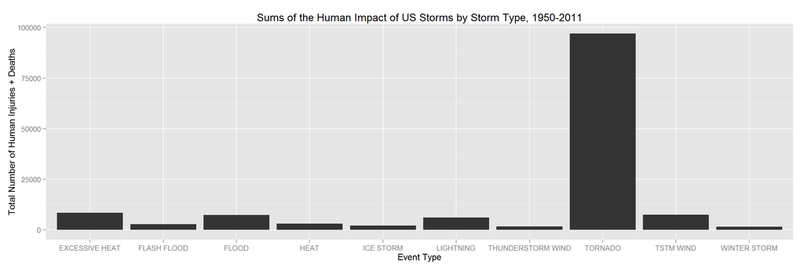

```r
ggplot(head(human_impact, n = 10), aes(x=EVTYPE, y = TotalImpact)) +
    geom_bar(stat = "identity") +
    xlab("Event Type") +
    ylab("Total Number of Human Injuries + Deaths")+
    ggtitle("Sums of the Human Impact of US Storms by Storm Type, 1950-2011")
```

The below table displays the storm types that caused the most property and crop damage from 1950-2011.

```r
econ_impact <- arrange(econ_impact, desc(TotalDamage))
print(head(econ_impact, n = nrow(econ_impact)/5))
```

```
## Source: local data frame [81 x 4]
##
##               EVTYPE   TotalProp   TotalCrop TotalDamage
##               (fctr)       (dbl)       (dbl)       (dbl)
## 1  HURRICANE/TYPHOON 69305840000  2607872800 71913712800
## 2        STORM SURGE 43323536000        5000 43323541000
## 3            DROUGHT  1046106000 13972566000 15018672000
## 4          HURRICANE 11868319010  2741910000 14610229010
## 5        RIVER FLOOD  5118945500  5029459000 10148404500
## 6     TROPICAL STORM  7703890550   678346000  8382236550
## 7           WILDFIRE  4765114000   295472800  5060586800
## 8   STORM SURGE/TIDE  4641188000      850000  4642038000
## 9     HURRICANE OPAL  3172846000    19000000  3191846000
## 10  WILD/FOREST FIRE  3001829500   106796830  3108626330
## ..               ...         ...         ...         ...
```

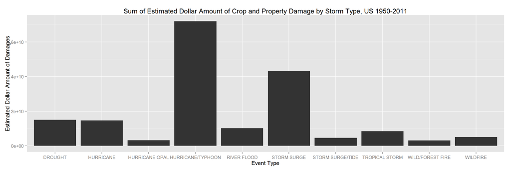

```r
ggplot(head(econ_impact, n=10), aes(x=EVTYPE, y = TotalDamage)) +
    geom_bar(stat = 'identity') +
    xlab("Event Type") +
    ylab("Estimated Dollar Amount of Damages") +
    ggtitle("Sum of Estimated Dollar Amount of Crop and Property Damage by Storm Type, US 1950-2011")
```